# Movie Night

Kelly Thackeray, Judy Camarena

2024-04-25

### Introduction

The datasets used for this report are CSV files from Kaggle named IMDB Movie dataset from and Highest_Holywood_Grossing_Movies. The datasets reflect movie sales.

### Problem Statement and Questions

To understand movie industry sales trends and the role distributors play.

#### Distributor

- Worldwide sales per distributor
- Top 10 sales per year per distributor
- Top directors per distributor
- Lowest sales of distributors

We can begin by examining an overview with this chart and graph.

#### Number of Movies Released Over the Last 30 Years per Year

| Year Released | Movies |
| --- | --- |
| 2014 | 12 |
| 2009 | 10 |
| 2010 | 10 |
| 2012 | 8 |
| 2001 | 7 |
| 2019 | 7 |
| 2008 | 6 |
| 2015 | 6 |
| 2016 | 6 |
| 2017 | 6 |
| 2018 | 6 |
| 2002 | 5 |
| 2003 | 5 |
| 2006 | 5 |
| 2013 | 5 |
| 1994 | 4 |
| 1999 | 4 |
| 2004 | 4 |
| 1995 | 3 |
| 2005 | 3 |
| 2007 | 3 |
| 1997 | 2 |
| 2000 | 2 |
| 2011 | 2 |
| 1998 | 1 |

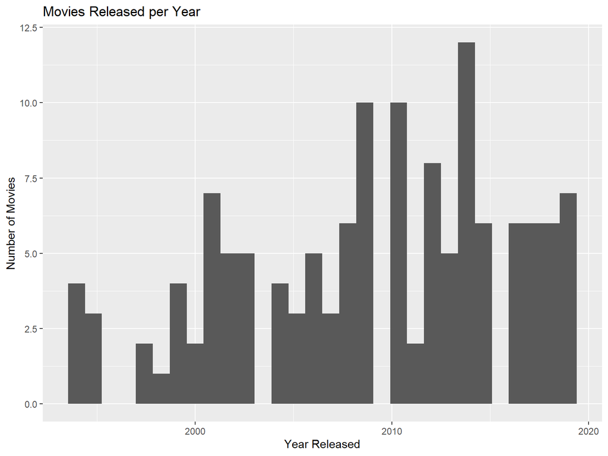

# Sales per Release Year

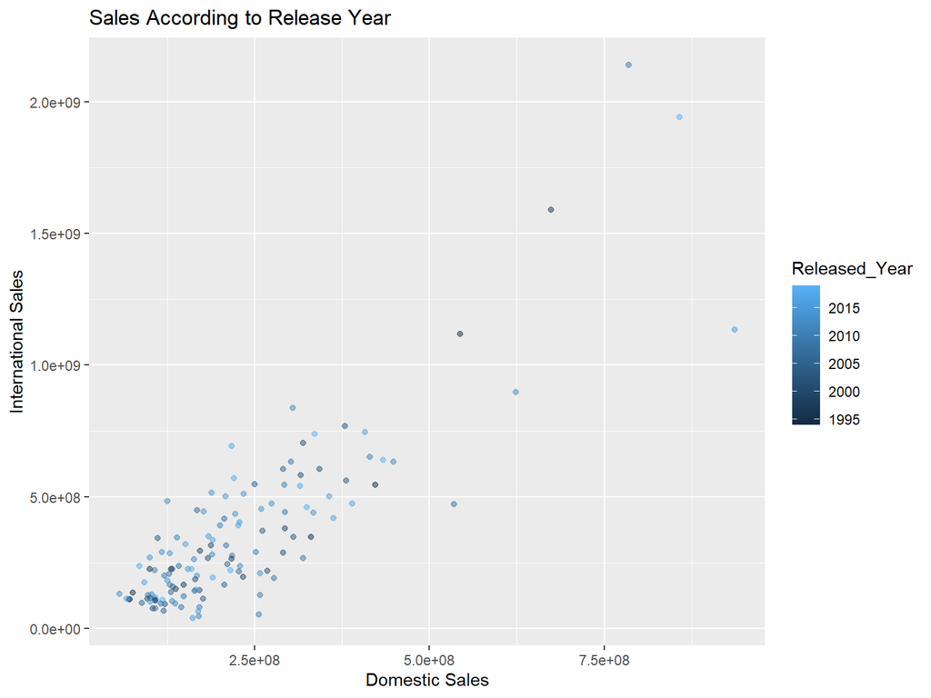

# Domestic Sales

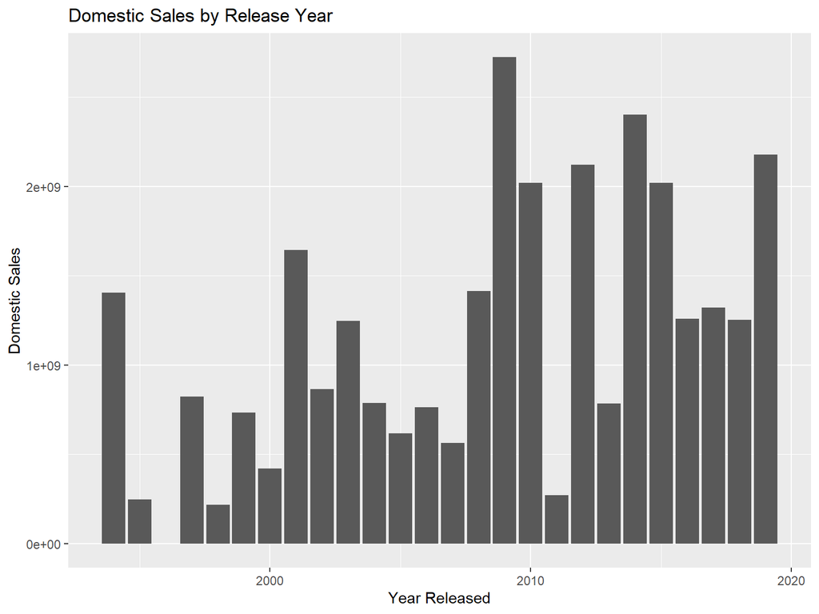

# International Sales

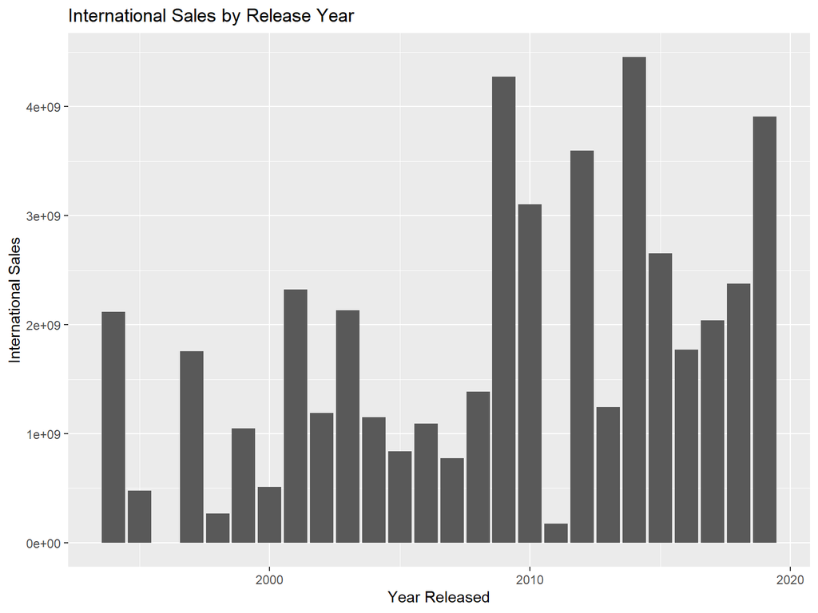

# Sales per Budget

[figure not shown]

# Domestic Sales and Budget

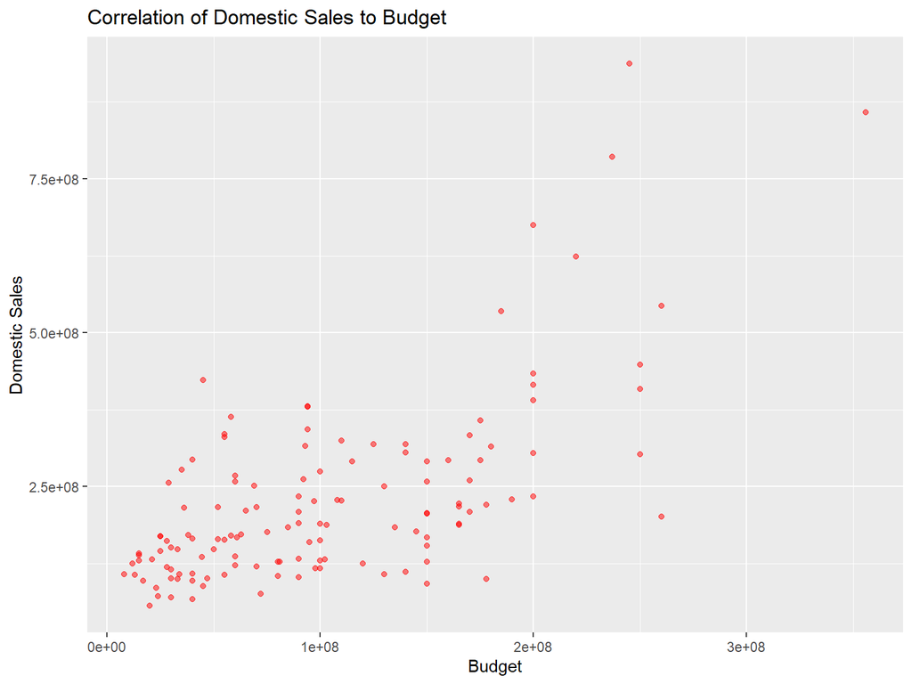

# International Sales and Budget

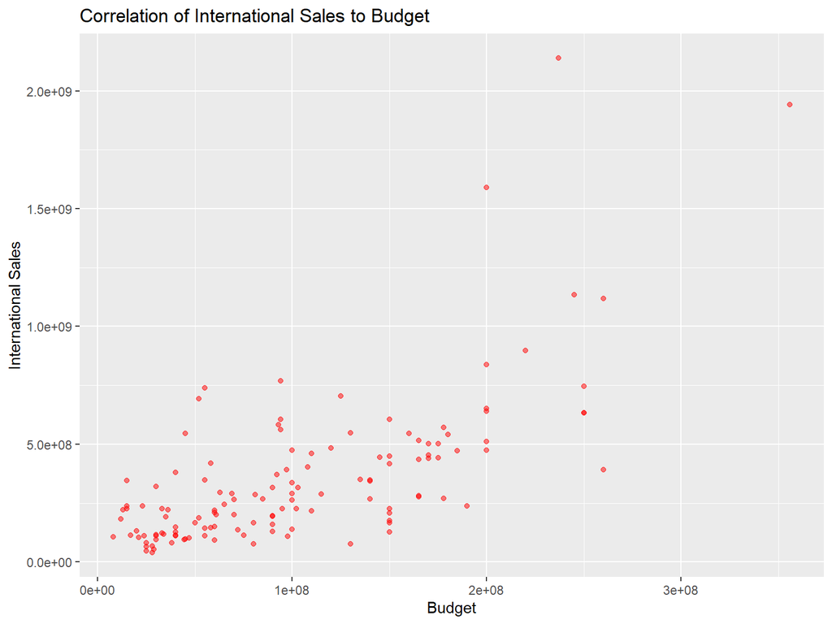

# Domestic vs. International Sales

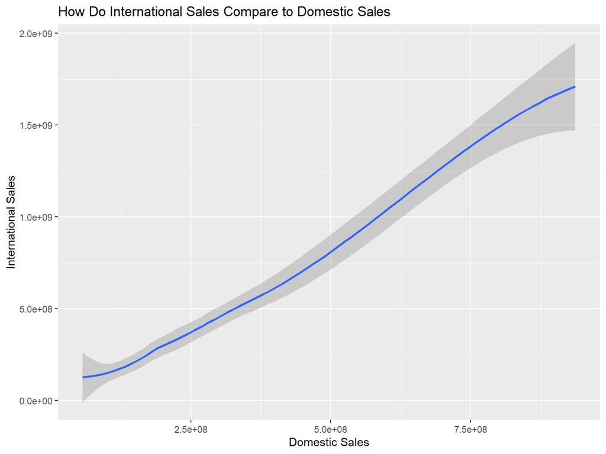

It is indicated that 2009, 2010, and 2014 released the most movies per year.

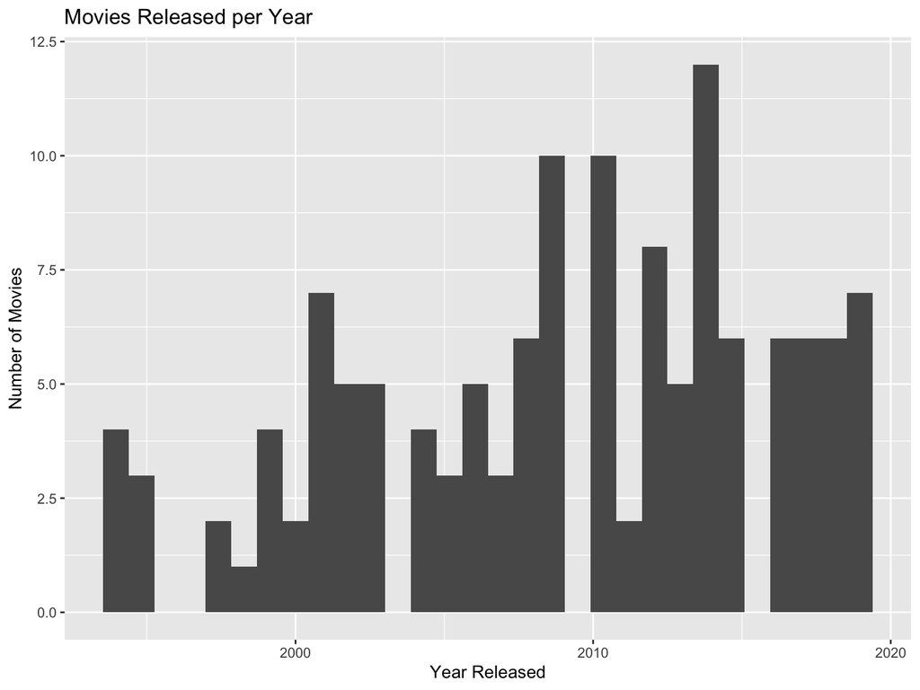

*Now that we know what years released the most movies, we wanted to plot domestic and international sales yearly. We were expecting the data to show us the same trends.*

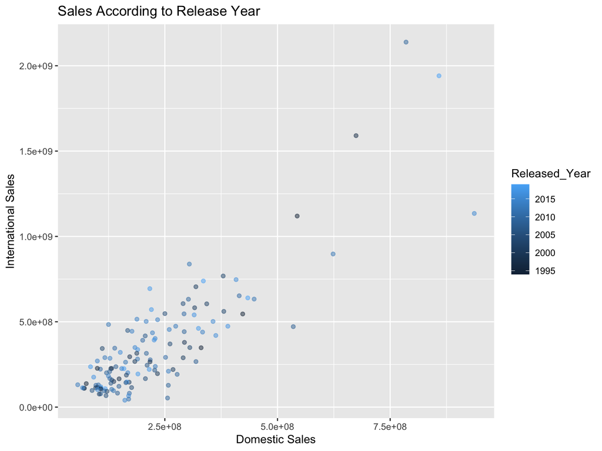

The data told a different story.

We investigated further by only looking into domestic sales.

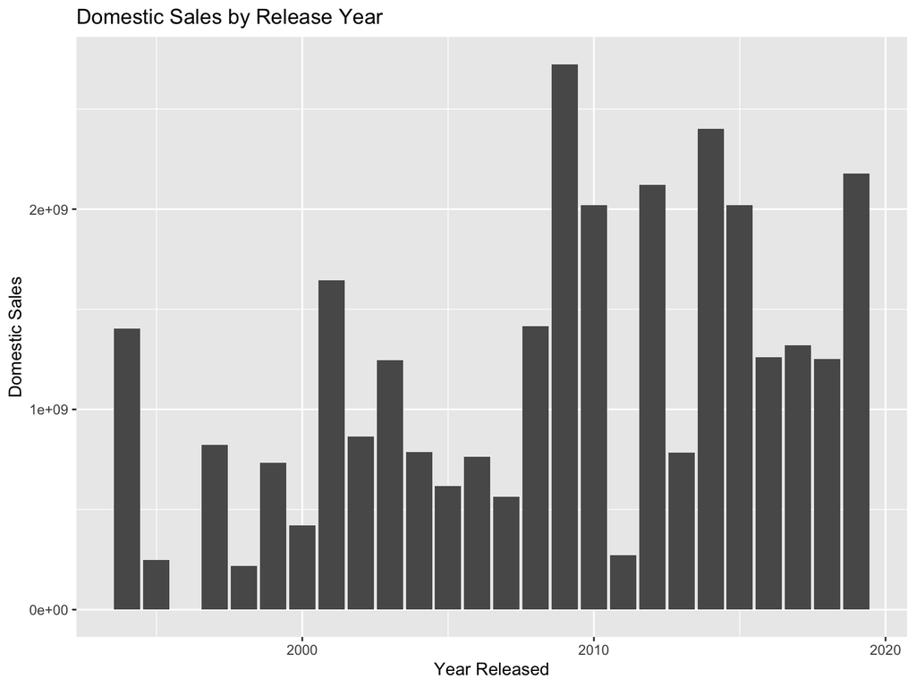

When we took a look at international sales…

#### International Sales

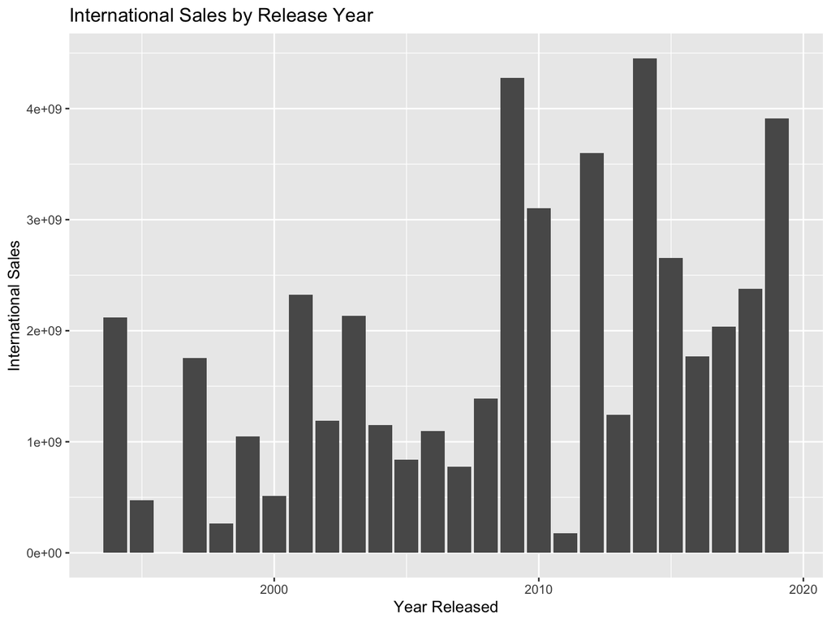

The data showed 2014 and 2009 as the most lucrative year in sales.

Noting the difference in movie release years versus the highest-grossing years prompted us to look into sales per budget.

[figure not shown]

We decided to look more closely into domestic sales and budgets to identify trends.

#### Domestic sales and budget

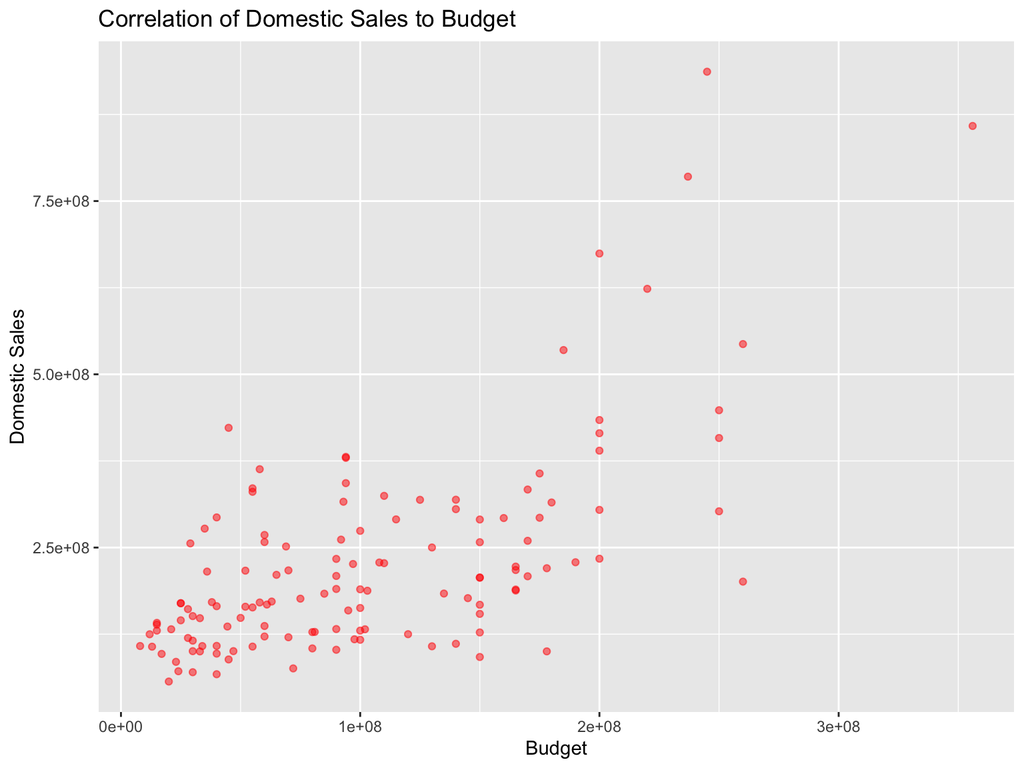

When we plotted the same data for international sales and budgets similar conclusions were reached.

#### International Sales and Budget

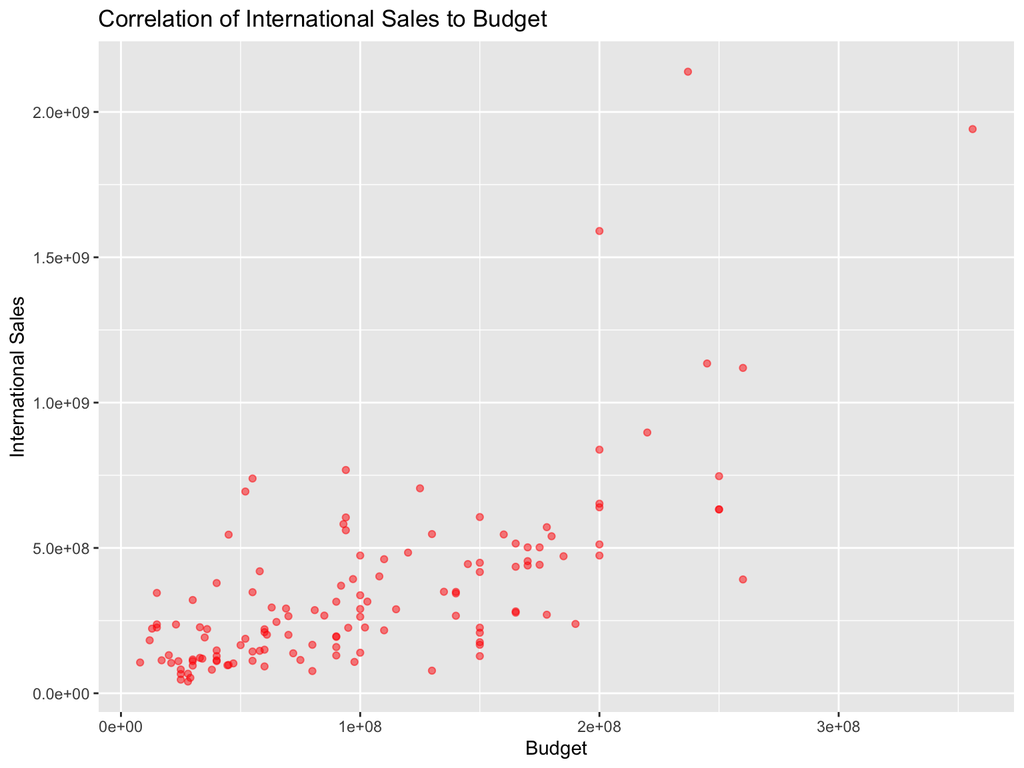

Next, we wanted to compare domestic sales to international sales.

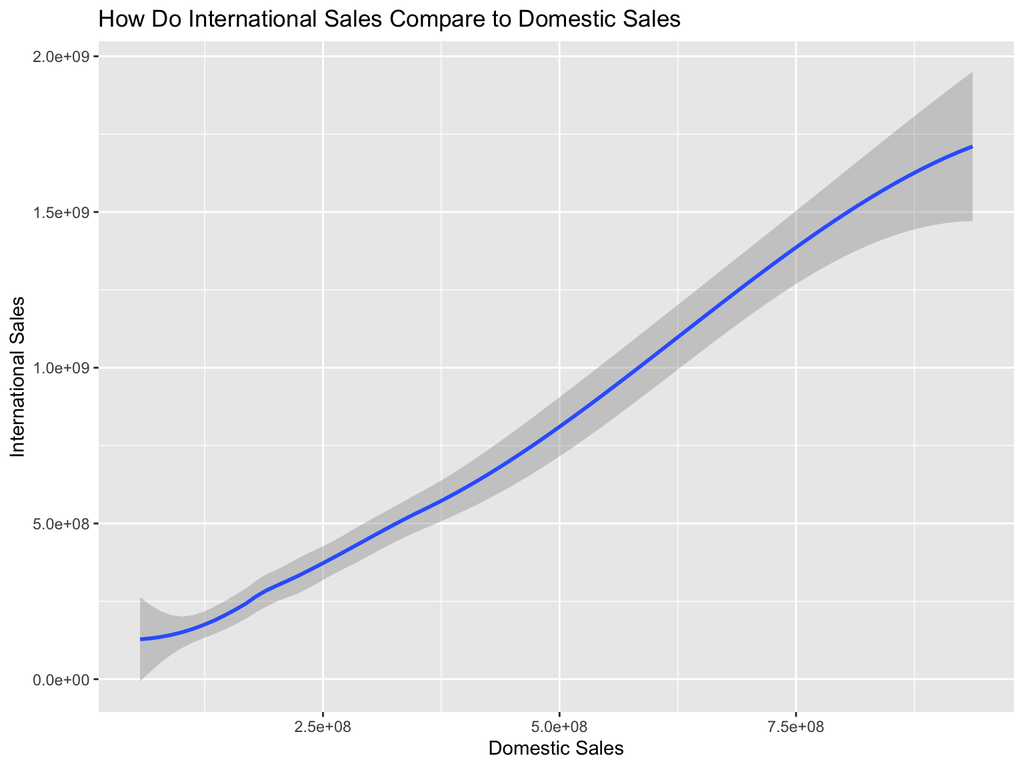

| Movie Name | Domestic Sales | International sales |
| --- | --- | --- |
| Avatar | 785221649 | 2138484377 |
| Avengers: Endgame | 858373000 | 1941066100 |
| Titanic | 674292608 | 1590450697 |
| Star Wars: Episode VII - The Force Awakens | 936662225 | 1134647993 |
| The Lion King | 543638043 | 1119437358 |
| The Avengers | 623357910 | 897180626 |
| Captain America: Civil War | 408084349 | 746962067 |
| The Lord of the Rings: The Return of the King | 379427292 | 768206541 |
| Skyfall | 304360277 | 838111018 |
| The Dark Knight Rises | 448149584 | 633020241 |

# Correlation Opening Weekend and Total Sales

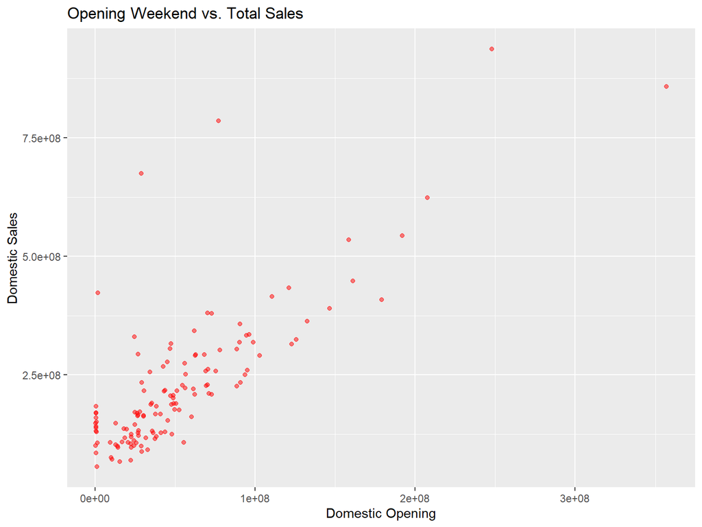

# Distribution

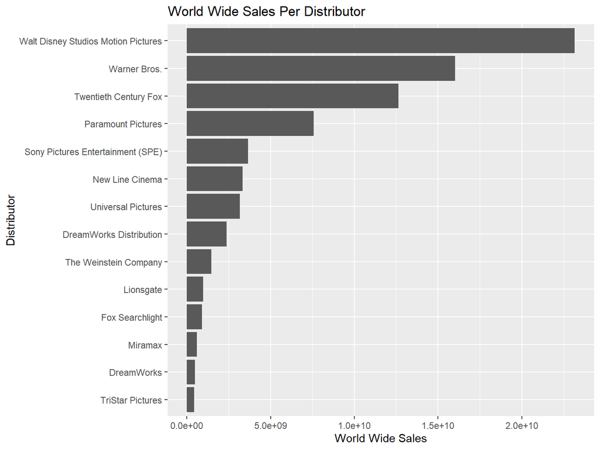

[figure not shown]

Movies depend on their distribution. So, we wanted to identify our largest distributor.

#### Distribution

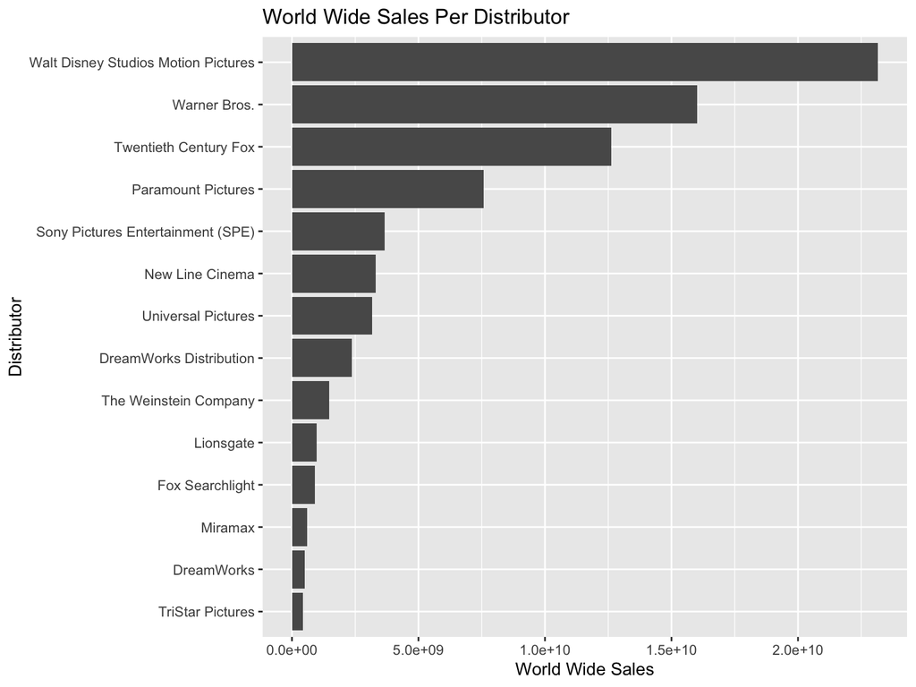

We concluded that Walt Disney Studios was our largest worldwide distributor.

We wanted to know which year each distributor had reported the highest sales. To narrow our search, we limited the dataset to only list the top 10 sales.

#### Top 10 Sales per Year per Distributor

| Distributor | Year Released | Total Sales |
| --- | --- | --- |
| Walt Disney Studios Motion Pictures | 2019 | 2799439100 |
| Warner Bros. | 2019 | 1074458282 |
| Walt Disney Studios Motion Pictures | 2019 | 1073841394 |
| Universal Pictures | 2019 | 384579472 |
| Lionsgate | 2019 | 312897920 |
| Twentieth Century Fox | 2019 | 225508210 |
| Sony Pictures Entertainment (SPE) | 2019 | 218843645 |
| Twentieth Century Fox | 2018 | 910809311 |
| Paramount Pictures | 2018 | 791657398 |
| Twentieth Century Fox | 2018 | 785896609 |

As we tried to identify what could make a movie more profitable, we decided to look at the top directors per distributor. We wanted to know how many movies each director produced and who they used as their distributor.

#### Top Directors per Distributor

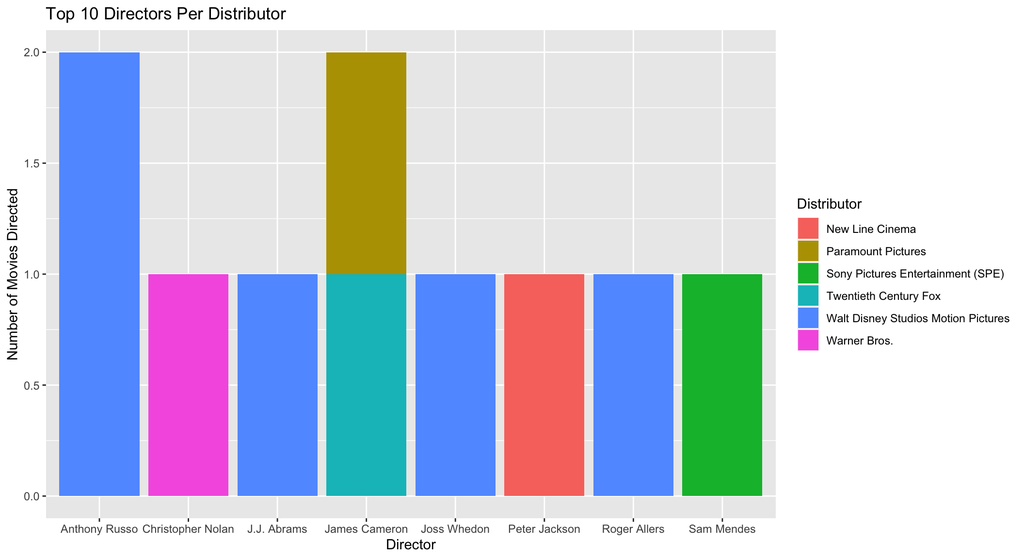

# Top Directors per Distributor

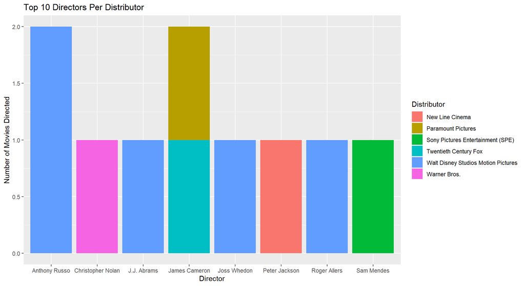

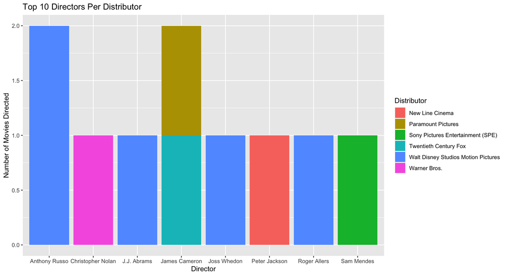

# Lowest Sales of Distributors

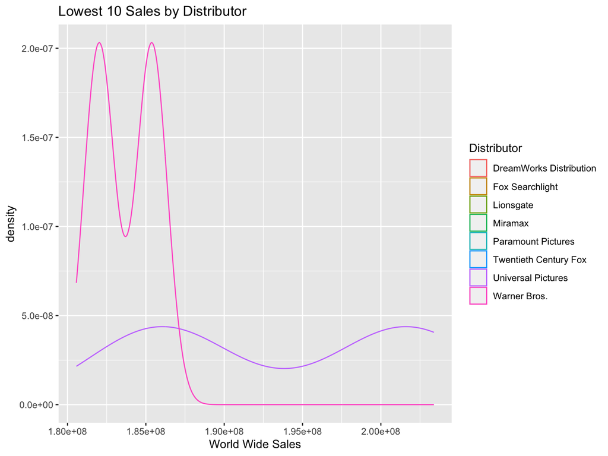

### Summary

It is important to consider that the data did not measure or account for numerous factors beyond anyone’s control, like weather, social, or economic factors that have impacted movie sales.